# Lab assignment 4

```r
library(tidyverse)
library(forcats)
```

## Alienchef

In this competition, two chefs have to prepare a soup as fast as possible. They are timed on how fast they can chop vegetables and how fast they can cook them.

The dataset in the file `alienchef.csv` reports the times in seconds for chefs `Scraf` and `Blorg`.

```r
alienchef <- read_csv("alienchef.csv")
alienchef
```

| chef | task | time |
| --- | --- | --- |
| Scraf | chopping | 120 |
| Blorg | chopping | 240 |
| Scraf | cooking | 660 |
| Blorg | cooking | 720 |

- Build a stacked bar chart where the `time` is mapped to `y`, the `chef` is mapped to `x` and the `task` is encoded with `fill`.
  - If you want to convey the message that both chefs employ approximately the same time to cook the vegetables, how would you organize the stacked columns?

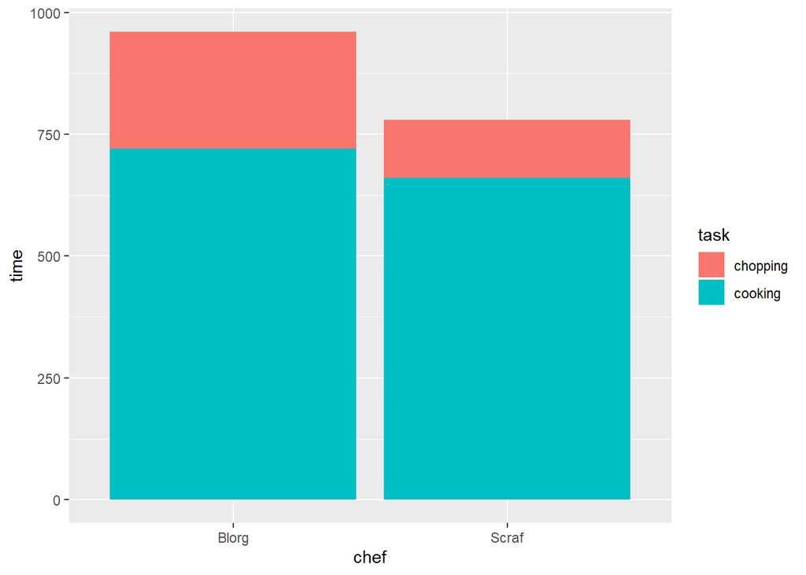

```r
# your code here
alienchef%>%
ggplot(mapping = aes( x=chef ,y = time, fill = task)) +
geom_col()
```

- If instead, you wanted to stress that Scraf is faster at chopping, how whould you organize the columns (*hint*: use `fct_reorder`)?

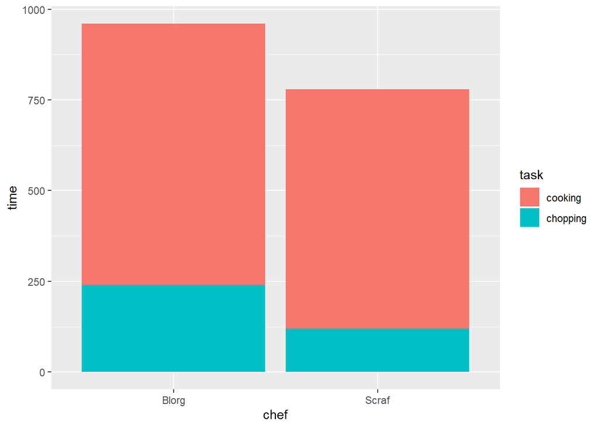

```r
# your code here
alienchef%>%
  mutate(task = fct_reorder(task,desc(time)))%>%
  ggplot(mapping = aes( x=chef ,y = time, fill = task)) +
  geom_col()
```

## US politics

The `gss_cat` dataset, from the `forcats` package contains information about surveys in the US from 2000 to 2014. Among the several columns, the `partyid` column reports the party that each survey respondent belongs to. The type of this columns is `factor`.

```r
# Get the distinct values of `partyid` using the `distinct` function from `dplyr`.
gss_cat%>%
  distinct(partyid)
```

| partyid |
| --- |
| Ind,near rep |
| Not str republican |
| Independent |
| Not str democrat |
| Strong democrat |
| Ind,near dem |
| Strong republican |
| Other party |
| No answer |
| Don't know |

You see that there 10 different parties. These might be too many for a visualization. The function `fct_collapse` from `forcats` allows you to collapse the levels of a factor in several manually specified groups. After reading the help page for `fct_collapse`, complete the following code snippet

```r
  # use the `count` function to compute the number of people
  # for each year and partyid
parties <- gss_cat %>%
  mutate(partyid = fct_collapse(partyid,
    other = c("No answer", "Don't know", "Other party"),
    # complete the code here
    republican = c("Strong republican","Not str republican"),
    independent = c("Ind,near rep", "Independent", "Ind,near dem"),
    democrat = c("Not str democrat", "Strong democrat")
  )) %>%
  count(year,partyid)
  # use the `count` function to compute the number of people
  # for each year and partyid

parties
```

| year | partyid | n |
| --- | --- | --- |
| 2000 | other | 60 |
| 2000 | republican | 684 |
| 2000 | independent | 1152 |
| 2000 | democrat | 921 |
| 2002 | other | 84 |
| 2002 | republican | 764 |
| 2002 | independent | 994 |
| 2002 | democrat | 923 |
| 2004 | other | 41 |
| 2004 | republican | 821 |

[output cut: 22 more lines]

Now that we have reduced the number of categories, plot how the proportion of democrats, republicans, independent, and “other” changed throught the years. You can use `geom_area` with the `"fill"` position for this task.

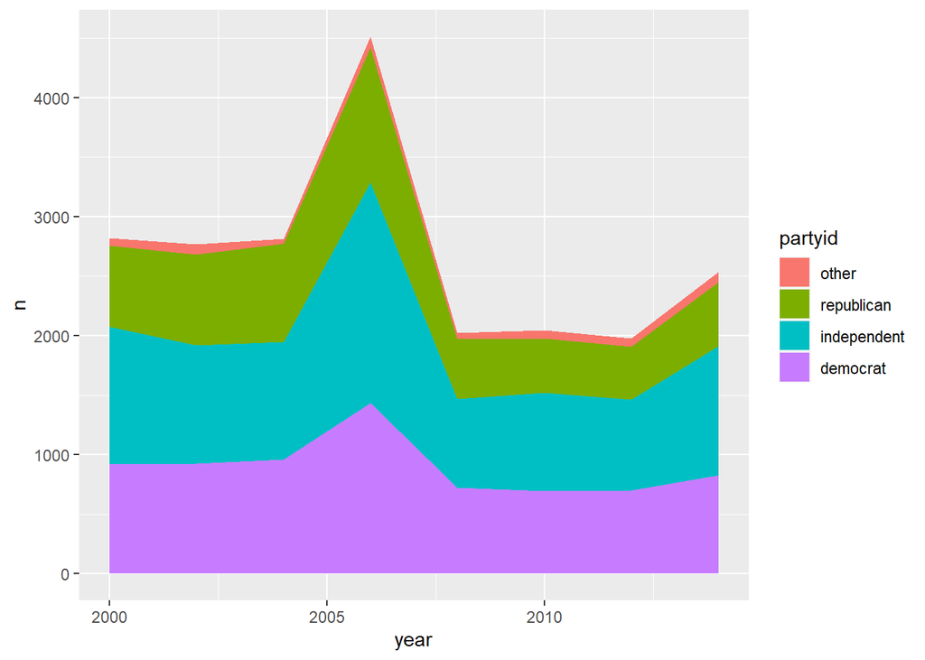

```r
# Your code here
ggplot(parties,aes(x = year,y=n,fill=partyid))+geom_area()
```

If we were to use the original categories for `partyid`, what problem would we have when making the plot?